# Analysing_qPCR template for Calculating primer efficiencies

Adrija Kalvisa

14/01/2020

### About this analysis

The sample loading schemes usually are in a “wide” format (imitating the 96 or 384 well PCR plate layout) while the Cp values are obtained in a “long” format. In order to avoid time-consuming and error-prone manual conversion from one format to another, this script provides a framework to automatize merging the loading scheme and Lightcycler output. The script uses path to Loading scheme (in .xls format) where each well information is stored from B2:M10 cells.

## Step 1: define input files

This part you have to change:

```r
#pathToSampleLayout = "qPCR SMARCE1 Molm13.xlsx"
#pathToCpValues = "SMARCE1_Lightcycler480_output.txt"

# if the file is in the same folder as this script then you can provide only the sample name.
pathToSampleLayout = "12Sept2019-validation primers test.xlsx"
pathToCpValues = "primer_validation_Cp_values.txt"

referencePrimers="B2M"
```

The rest of the script should work without your supervision. I suggest, however, double checking that the right bits are asigned to “primer”, “treatment”, “biological_replicate”, “technical_replicate” and “primer_ratio” columns. This bit can be modifoed in ‘Load Sample Layout’ section.

## Step 2: set up the environment

**load libraries**

```r
library(readxl)

#install.packages("platetools")
library(platetools)

#install.packages("pcr")
library(pcr)

# install.packages(“ggplot2”)
library(ggplot2)

# install.packages("viridis")
library(viridis)

# install.packages(“reshape2”)
library(reshape2)

# install.packages("dplyr")
library(dplyr)

# install.packages("tidyr")
library(tidyr)
```

**Custom-made functions**

`entry2columns(my_column, list_of_informative_cathegories, separator_string)`  
separates sample information into relevant user-specified cathegories (“primer”, “treatment”, “biological_replicate”, “technical_replicate”, “primer_ratio”).

examples for using the `entry2columns()` function:

```r
# ideally the column names should be some of the following:
# "primer", "treatment", "biological_replicate", "technical_replicate", "primer_ratio"

"PrimerABC_treatmentDEF_repGHI" %>% entry2columns(c("primer", "treatment", "biological_replicate"), "_")
```

```
##      primer      treatment      biological_replicate
## [1,] "PrimerABC" "treatmentDEF" "repGHI"
```

```r
"PrimerABC-treatmentDEF repGHI" %>% entry2columns(c("primer", "treatment", "biological_replicate"), "-| ")
```

```
##      primer      treatment      biological_replicate
## [1,] "PrimerABC" "treatmentDEF" "repGHI"
```

```r
"PrimerABC-treatmentDEF repGHI 1:100" %>% entry2columns(c("primer", "treatment", "biological_replicate", "primer_ratio"), "-| ")
```

```
##      primer      treatment      biological_replicate primer_ratio
## [1,] "PrimerABC" "treatmentDEF" "repGHI"             "1:100"
```

`transformWellNumbers(posString)` turns numbers “A1”" “B2” “C3” to “A01” “B02” “C03”.

`readFromFile_CpValues(pathToFile)` reads the output .txt file from Lightcycler480 machine.

`plate2table(dataFrame)` transforms the sample layout from “wide” to “long” format.

`meanWithoutNA` calculates means of Cp when some values are missing

`ratio2conc("characterString")` turns primer ratio (“1:100”) into relative primer concentration (“0.01”)

### Step 3: Load sample Layout

```r
# load sample layout
primer_validation_sample_layout = readFromFile_SampleLayout(pathToSampleLayout)
# turn sample layout into "long" list format
sample_list = plate2table(primer_validation_sample_layout)

# split the loading information into separate columns and add the new columns back to the long table
sample_list = sample_list$value %>% entry2columns(c("primer", "primer_ratio"), " ") %>% cbind(sample_list)
```

`entry2columns(c("primer", "primer_ratio"), " ")` splits the column into two new columns by splitting the column where the space `"" "` is. Note that if you have several different delimiters, you can separate them with a `|` which means `OR`. For example, `"-| "` will be used to split “RNF141-1 1:100” into “RNF141” “1” “1:100”.

```r
# make sure that each well has an unique naming - I assume that identical come from "technical replicates"
sample_list =
  sample_list %>%
  group_by(primer, primer_ratio) %>%
  mutate(technical_replicate = row_number()) %>%
  select(-"value")
```

`group_by(primer, primer_ratio)` finds the unique combinations of primer+primer_ratio  
`mutate(technical_replicate = row_number())` counts how many times these unique values were encountered and saves these counts in column named ‘technical replicate’ `select(-"value")` drops the column named ‘value’ from sample_list because it has become redundant

how does sample list look like?

```r
sample_list
```

```
## # A tibble: 96 x 4
## # Groups:   primer, primer_ratio [33]
##    primer   primer_ratio Pos   technical_replicate
##    <fct>    <fct>        <chr>               <int>
##  1 RNF141-1 1:1          A01                     1
##  2 RNF141-1 1:1          B01                     2
##  3 RNF141-1 1:1          C01                     3
##  4 RNF141-2 1:1          D01                     1
##  5 RNF141-2 1:1          E01                     2
##  6 RNF141-2 1:1          F01                     3
##  7 SETD4-1  1:1          G01                     1
##  8 SETD4-1  1:10         H01                     1
##  9 RNF141-1 1:10         A02                     1
## 10 RNF141-1 1:10         B02                     2
## # … with 86 more rows
```

show the Cp values in the plate layout

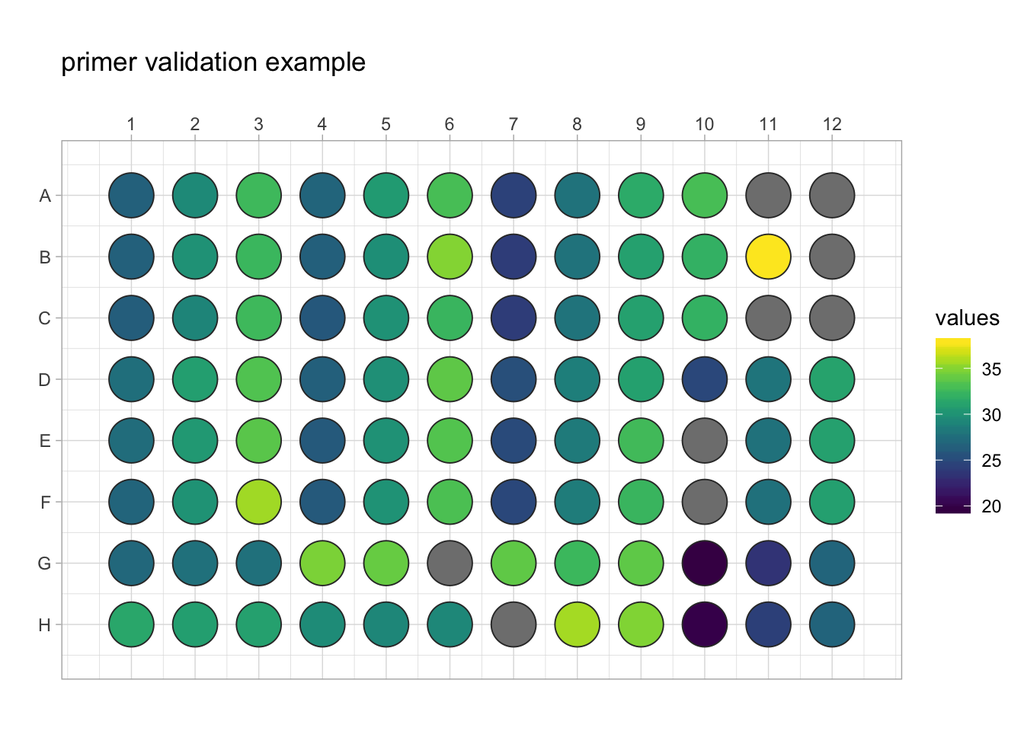

```r
# load Cp values
primer_validation_Cp_values = readFromFile_CpValues(pathToCpValues)

# show the plate layout
platetools::raw_map(
  data = primer_validation_Cp_values$Cp,
  well = primer_validation_Cp_values$Pos) +
  ggtitle("primer validation example") +
  theme_light() +
  scale_fill_viridis()
```

```r
# Merge Cp values with sample information
Samples_Cp_long =
  merge(sample_list, primer_validation_Cp_values, by="Pos")

# Extract dilution factor
Samples_Cp_long$primer_conc = ratio2conc(Samples_Cp_long$primer_ratio)
```

what primers are tested?

```r
Samples_Cp_long$primer %>% as.character() %>% unique()
```

```
##  [1] "RNF141-1"  "PHF3-1"    "SMARCE1-1" "SMN1-1"    "RNF141-2"
##  [6] "PHF3-2"    "SMARCE1-2" "SMN1-2"    "SETD4-1"   "SETD4-2"
## [11] "B2M"
```

Make a data frame where each column contains one primer set and each row contains one sample (1 sample = 1 eppendorf tube)

```r
data_for_pcr_table =
  Samples_Cp_long[Samples_Cp_long$primer != referencePrimers, c("primer","technical_replicate","primer_conc","Cp")]

pcr_table =
  tidyr::pivot_wider(
  data = data_for_pcr_table,
  names_from = primer,
  values_from = Cp,
  values_fn = list(Cp = meanWithoutNA)
  ) %>%
  select(-"technical_replicate")
```

how does pcr table look like?

```r
pcr_table
```

```
## # A tibble: 9 x 11
##   primer_conc `RNF141-1` `PHF3-1` `SMARCE1-1` `SMN1-1` `RNF141-2` `PHF3-2`
##         <dbl>      <dbl>    <dbl>       <dbl>    <dbl>      <dbl>    <dbl>
## 1        1          26.5     26.9        24.4     33.0       27.6     26.5
## 2        0.1        29.4     30.6        27.8    NaN         30.8     29.8
## 3        0.01       32.5     33.0        31.6    NaN         33.3     33.8
## 4        1          26.5     26.5        24.1     32.0       27.4     26.0
## 5        0.1        29.9     29.7        27.8     37.8       30.4     29.9
## 6        0.01       32.4     34.9        31.0    NaN         33.6     33.4
## 7        1          26.4     25.9        24.1     32.0       26.9     26.0
## 8        0.1        29.1     29.9        27.9    NaN         30.1     30.0
## 9        0.01       32.6     32.4        31      NaN         35.6     33.1
## # … with 4 more variables: `SMARCE1-2` <dbl>, `SMN1-2` <dbl>,
## #   `SETD4-1` <dbl>, `SETD4-2` <dbl>
```

```r
pcr_assess(
  df = pcr_table[,-1],
  amount = pcr_table$primer_conc,
  method = 'standard_curve')
```

```
##         gene intercept     slope r_squared
## 1   RNF141-1  26.47556 -3.003333 0.9932422
## 2     PHF3-1  26.48444 -3.483333 0.9429760
## 3  SMARCE1-1  24.25056 -3.501667 0.9949026
## 4     SMN1-1  32.33667 -5.483333        NA
## 5   RNF141-2  27.17778 -3.460000 0.9491483
## 6     PHF3-2  26.21222 -3.623333 0.9950236
## 7  SMARCE1-2  25.06944 -3.461667 0.9733275
## 8     SMN1-2  24.73000 -3.113333        NA
## 9    SETD4-1  27.48821 -3.472051        NA
## 10   SETD4-2  29.67282 -3.048205        NA
```

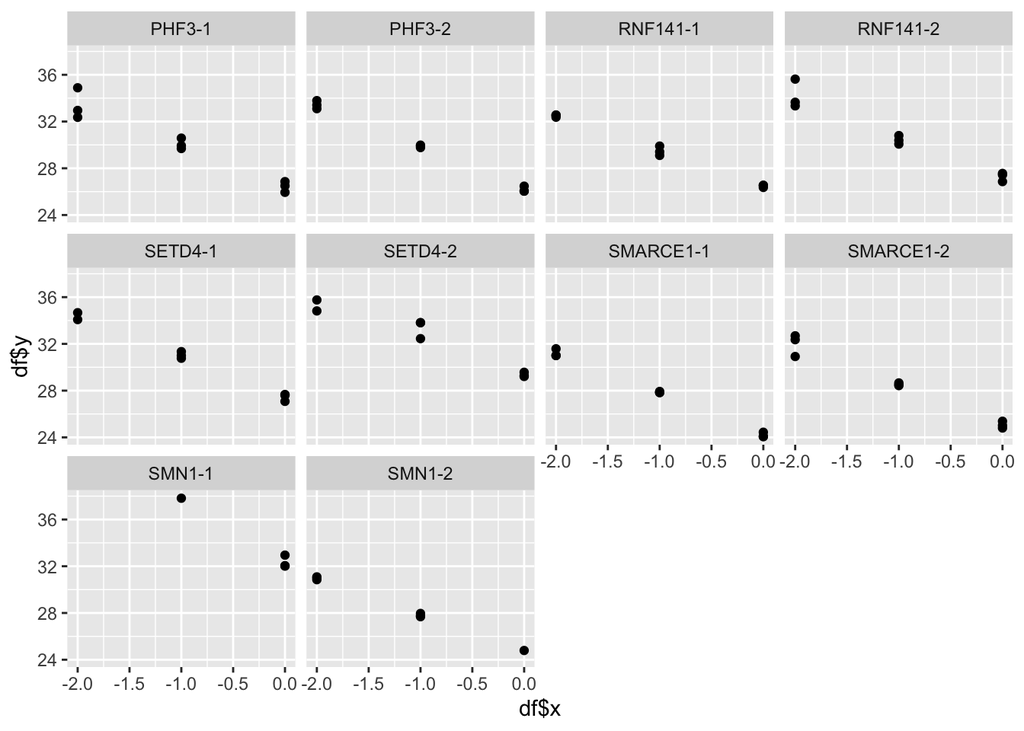

```r
# plot the slope
pcr_assess(
 df = pcr_table[,-1],
 amount = pcr_table$primer_conc,
 method = 'standard_curve',
 plot=TRUE)
```

More analysis tips: https://cran.r-project.org/web/packages/pcr/vignettes/qpcr_analysis.html

## Further analysis

More guidelines on analysing PCR results can be found in [pcr package vignette](https://cran.r-project.org/web/packages/pcr/vignettes/qpcr_analysis.html)